# US Health Expenditure Analysis

Deepti

The data were from the Medical Expenditure Panel Survey(MEPS). MEPS is a probability survey that provides nationally representative survey estimates of health care use, expenditures, sources of payment, and insurance coverage for the U.S. civilian population.

##### We will be analysising the parameters which are impacting health expenditure

Looking at the strutcure of data:

```r
str(health)
```

```
## 'data.frame':    2000 obs. of  29 variables:
##  $ ID         : int  1 2 3 4 5 6 7 8 9 10 ...
##  $ AGE        : int  30 56 55 47 50 45 25 61 50 19 ...
##  $ ANYLIMIT   : int  0 1 1 0 0 0 0 0 0 0 ...
##  $ COLLEGE    : int  0 0 1 1 1 1 0 0 1 0 ...
##  $ HIGHSCH    : int  0 1 0 0 0 0 1 1 0 0 ...
##  $ GENDER     : int  0 0 0 1 1 1 0 1 0 1 ...
##  $ MNHPOOR    : int  0 0 0 0 0 0 0 0 0 0 ...
##  $ insure     : int  0 1 1 1 1 1 1 0 1 1 ...
##  $ USC        : int  0 1 1 1 1 1 0 1 1 0 ...
##  $ UNEMPLOY   : int  0 1 0 0 1 1 0 0 0 0 ...
##  $ MANAGEDCARE: int  0 1 0 0 1 1 1 0 0 1 ...
##  $ famsize    : int  3 3 2 2 1 4 1 2 6 6 ...
##  $ COUNTIP    : int  0 0 2 0 0 0 0 0 0 0 ...
##  $ EXPENDIP   : num  0 0 16121 0 0 ...
##  $ COUNTOP    : int  0 5 42 4 43 5 0 4 0 24 ...
##  $ EXPENDOP   : num  0 2385 29730 110 3299 ...
##  $ RACE       : Factor w/ 5 levels "ASIAN","BLACK",..: 5 2 5 2 5 5 5 5 5 5 ...
##  $ RACE1      : int  4 2 4 2 4 4 4 4 4 4 ...
##  $ REGION     : Factor w/ 4 levels "MIDWEST","NORTHEAST",..: 1 3 1 2 4 1 4 1 4 4 ...
##  $ REGION1    : int  2 3 2 1 0 2 0 2 0 0 ...
##  $ EDUC       : Factor w/ 3 levels "COLLEGE","HIGHSCH",..: 3 2 1 1 1 1 2 2 1 3 ...
##  $ EDUC1      : int  0 1 2 2 2 2 1 1 2 0 ...
##  $ MARISTAT   : Factor w/ 4 levels "DIVSEP","MARRIED",..: 2 2 2 2 1 2 3 2 2 3 ...
##  $ MARISTAT1  : int  1 1 1 1 3 1 0 1 1 0 ...
##  $ INCOME     : Factor w/ 5 levels "HINCOME","LINCOME",..: 3 3 1 1 2 3 2 1 3 3 ...
##  $ INCOME1    : int  3 3 4 4 2 3 2 4 3 3 ...
##  $ PHSTAT     : Factor w/ 5 levels "EXCE","FAIR",..: 1 3 1 2 3 5 5 5 5 1 ...
##  $ PHSTAT1    : int  0 2 0 3 2 1 1 1 1 0 ...
##  $ INDUSCLASS : Factor w/ 12 levels "","FINANCE","LEISURE",..: 12 1 7 1 1 1 1 11 10 1 ...
```

which is summarised as follows:

**Continous Variables:** There are six continous variables- Age,famsize,countip, expendip, countop, expendop.

**Categotical Variables:** There are seven categorical variables- race, region, educ, maristat, income, phstat, indusclass.

Total 2000 observations with 22 variables.

It contains data for both Inpatients and outpatients expenditure, since we are analyzing outpatients expenditure, extracting outpatients data post removing redundant columns for categories.

```r
#removing redundant columns

health <- subset(health, select=-c(ID,RACE1,REGION1,EDUC1,MARISTAT1,INCOME1,PHSTAT1))

InpHealth<- subset(health,COUNTIP>0,select = -c(COUNTOP,EXPENDOP) )
dim(InpHealth)
```

```
## [1] 157  20
```

```r
OppHealth<- subset(health,COUNTOP>0,select = -c(COUNTIP,EXPENDIP) )
dim(OppHealth)
```

```
## [1] 1352   20
```

#### Missing Value Analysis

```r
detectmissing <- function(dataframe) {
    cnt <- 0
    # check number of columns
    nocol <- ncol(dataframe)
    norow <- nrow(dataframe)
    for (i in 2:nocol) {
        for (j in 1:norow) {
            if (dataframe[j, i] == "" | is.na(dataframe[j, i]))

            {
                cnt <- cnt + 1

            }
        }
        if (cnt > 0) {
            print(paste("There are missing values", cnt))
            print(paste("In column", colnames(dataframe[i])))
        }

    }
}

detectmissing(health)
```

```
## [1] "There are missing values 888"
## [1] "In column INDUSCLASS"
```

```r
# Replacing missing values to 'Others' in INDUSCLASS
health$INDUSCLASS <- as.character(health$INDUSCLASS)
class(health$INDUSCLASS)
```

```
## [1] "character"
```

```r
head(health$INDUSCLASS)
```

```
## [1] "TRANSINFO"   ""            "NATRESOURCE" ""            ""
## [6] ""
```

```r
for (i in 1:2000) {
    # if (is.na(health$INDUSCLASS[i]) )
    if (health$INDUSCLASS[i] == "") {
        health$INDUSCLASS[i] <- "Others"
    }

}

health$INDUSCLASS <- as.factor(health$INDUSCLASS)
class(health$INDUSCLASS)
```

```
## [1] "factor"
```

```r
# Reconfirming missings
detectmissing(health)
```

We found missing values only in one column i.e. Indusclass and imputated missing with another factor “Others”.

For analysis splitting tha data into training and validation set

```
## [1] 270  20
```

```
## [1] 1082   20
```

Now looking at the statistics of each variable

#### Continous Variable Analysis

```r
# Summarizing each variable
attach(OppHealth_train)

# Statistics of continous variables
describe(AGE)
```

```
##    vars    n  mean    sd median trimmed   mad min max range skew kurtosis
## X1    1 1082 40.68 13.08     41   40.58 16.31  18  65    47 0.03    -1.05
##     se
## X1 0.4
```

```r
describe(famsize)
```

```
##    vars    n mean   sd median trimmed  mad min max range skew kurtosis
## X1    1 1082 3.11 1.64      3    2.97 1.48   1  12    11 1.02     1.86
##      se
## X1 0.05
```

```r
describe(COUNTOP)
```

```
##    vars    n mean    sd median trimmed  mad min max range skew kurtosis
## X1    1 1082 8.49 14.71      4    5.36 4.45   1 167   166 5.16    35.91
##      se
## X1 0.45
```

```r
describe(EXPENDOP)
```

```
##    vars    n   mean      sd median trimmed    mad min      max    range
## X1    1 1082 1813.3 3510.98 620.81 1045.86 773.63   3 32291.61 32288.61
##    skew kurtosis     se
## X1 4.79    29.42 106.74
```

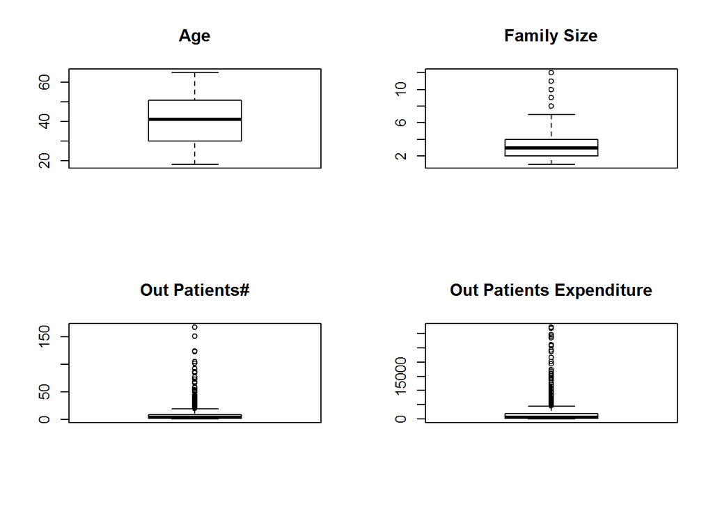

```r
par(mfrow = c(2, 2))
boxplot(AGE, main = "Age")
boxplot(famsize, main = "Family Size")
boxplot(COUNTOP, main = "Out Patients#")
boxplot(EXPENDOP, main = "Out Patients Expenditure")
```

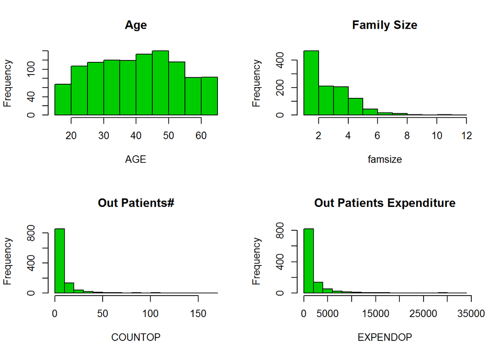

```r
hist(AGE, main = "Age", col = 3)
hist(famsize, main = "Family Size", col = 3)
hist(COUNTOP, main = "Out Patients#", col = 3)
hist(EXPENDOP, main = "Out Patients Expenditure", col = 3)
```

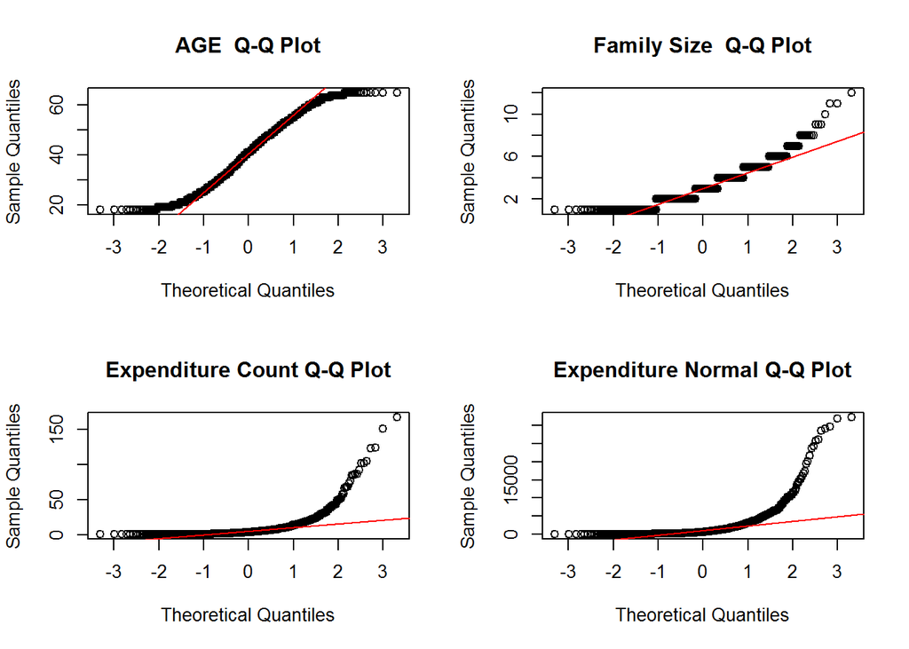

```r
par(mfrow = c(2, 2))
qqnorm(AGE, main = "AGE  Q-Q Plot", xlab = "Theoretical Quantiles", ylab = "Sample Quantiles",
    plot.it = TRUE, datax = FALSE)
qqline(AGE, col = 2)
qqnorm(famsize, main = "Family Size  Q-Q Plot", xlab = "Theoretical Quantiles",
    ylab = "Sample Quantiles", plot.it = TRUE, datax = FALSE)
qqline(famsize, col = 2)
qqnorm(COUNTOP, main = "Expenditure Count Q-Q Plot", xlab = "Theoretical Quantiles",
    ylab = "Sample Quantiles", plot.it = TRUE, datax = FALSE)
qqline(COUNTOP, col = 2)
qqnorm(EXPENDOP, main = "Expenditure Normal Q-Q Plot", xlab = "Theoretical Quantiles",
    ylab = "Sample Quantiles", plot.it = TRUE, datax = FALSE)
qqline(EXPENDOP, col = 2)
```

We can observe followings for the four continous variable viz box plot and histogram plots:

1. Age is distributed symmetrically around mean age of 40 with no outliers
2. Mean family size is 3, 50% population have family size between 1 to 3 and rest 50% between 4 to 7, rest are outliers lying out of whiskers. This making its histogram *right skewed*.
3. Mean count of out patients is 8 and most of the count is within 13 but outliers making it highly right skewed.
4. Mean out patients expenditure is 1.8K and most of the expenditure is within 5K but outliers making it highly right skewed.

#### Categorical Variable Analysis

Below are the frequency plots of categorical variable

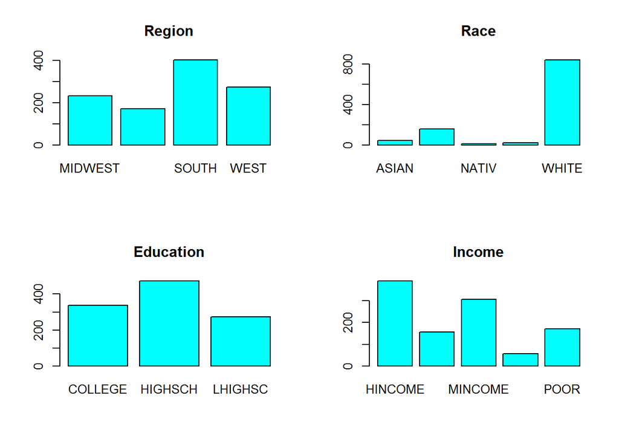

```r
# CDA
par(mfrow = c(2, 2))
barplot(table(REGION), main = "Region", col = 5)
barplot(table(RACE), main = "Race", col = 5)
barplot(table(EDUC), main = "Education", col = 5)
barplot(table(INCOME), main = "Income", col = 5)
```

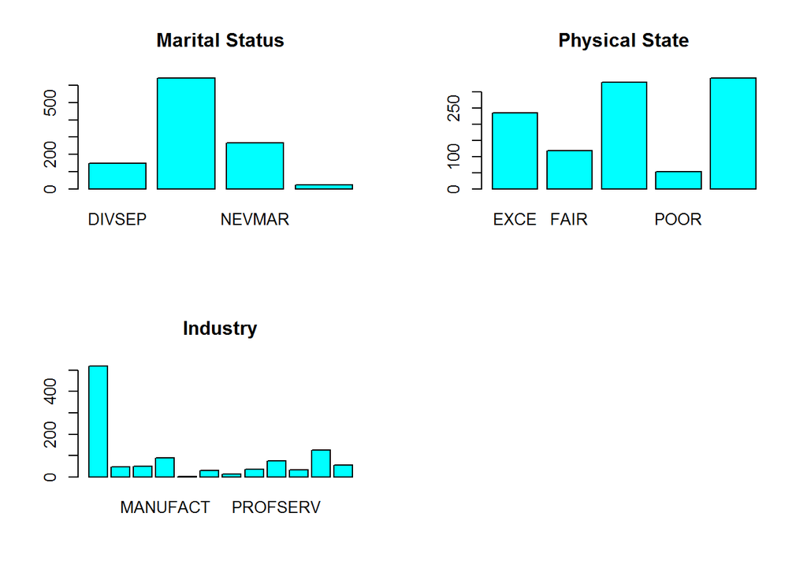

```r
par(mfrow = c(2, 2))
barplot(table(MARISTAT), main = "Marital Status", col = 5)
barplot(table(PHSTAT), main = "Physical State", col = 5)
barplot(table(INDUSCLASS), main = "Industry", col = 5)

# Box plot against expenditure
par(mfrow = c(2, 2))
```

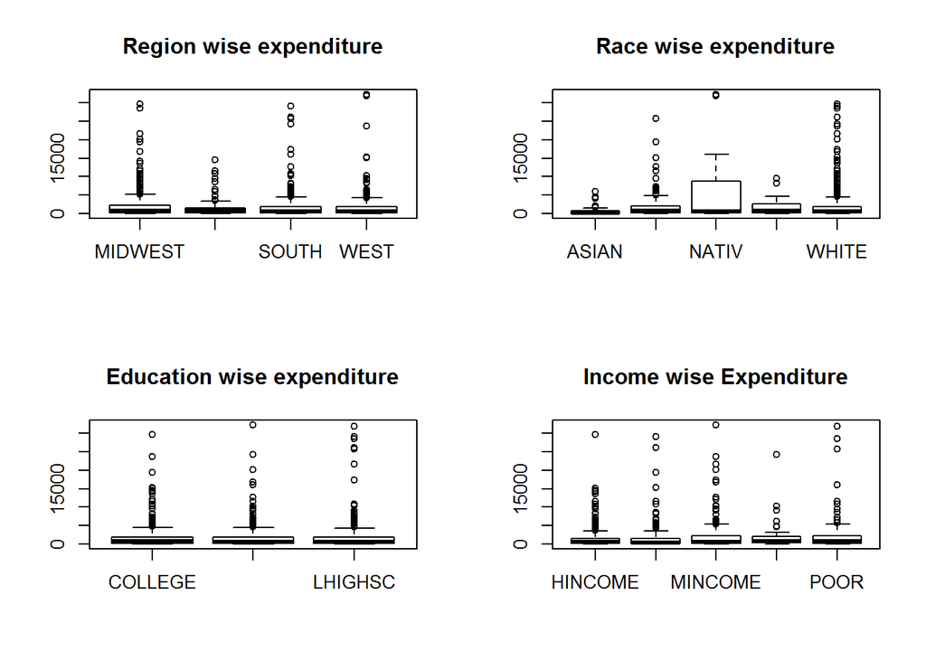

```r
boxplot(EXPENDOP ~ REGION, main = "Region wise expenditure")
boxplot(EXPENDOP ~ RACE, main = "Race wise expenditure")
boxplot(EXPENDOP ~ EDUC, main = "Education wise expenditure")
boxplot(EXPENDOP ~ INCOME, main = "Income wise Expenditure")
```

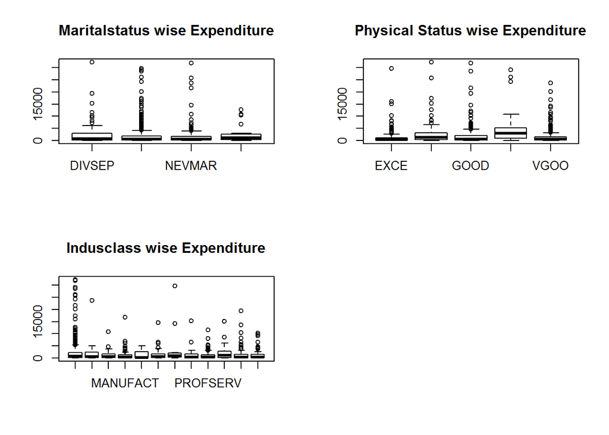

```r
par(mfrow = c(2, 2))
boxplot(EXPENDOP ~ MARISTAT, main = "Maritalstatus wise Expenditure")
boxplot(EXPENDOP ~ PHSTAT, main = "Physical Status wise Expenditure")
boxplot(EXPENDOP ~ INDUSCLASS, main = "Indusclass wise Expenditure")
```

#### Binary Variable Analysis

Below are the self explanatory frequency charts for each binary variable

```r
# Frequency Table for Binary Variables

table(UNEMPLOY)
```

```
## UNEMPLOY
##   0   1
## 815 267
```

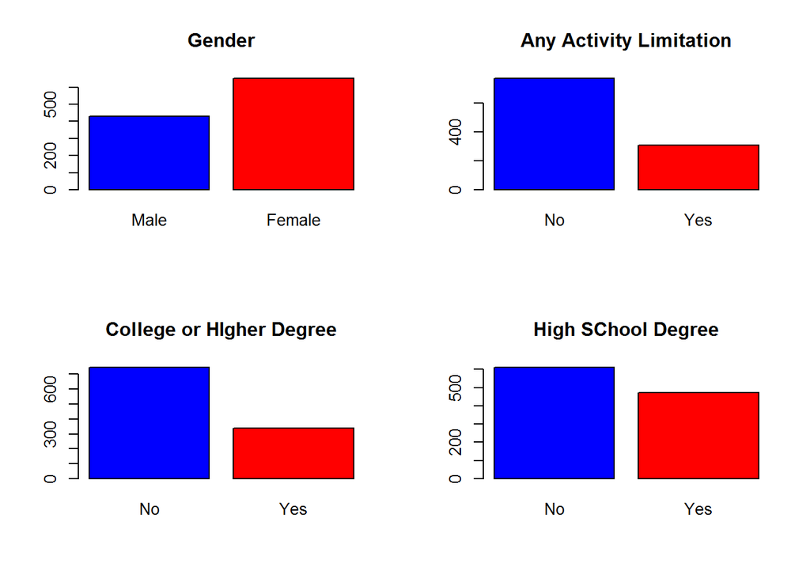

```r
par(mfrow = c(2, 2))
barplot(table(GENDER), names.arg = c("Male", "Female"), col = c("blue", "red"),
    main = "Gender")
barplot(table(ANYLIMIT), names.arg = c("No", "Yes"), col = c("blue", "red"),
    main = "Any Activity Limitation")
barplot(table(COLLEGE), names.arg = c("No", "Yes"), col = c("blue", "red"),
    main = "College or HIgher Degree")
barplot(table(HIGHSCH), names.arg = c("No", "Yes"), col = c("blue", "red"),
    main = "High SChool Degree")
```

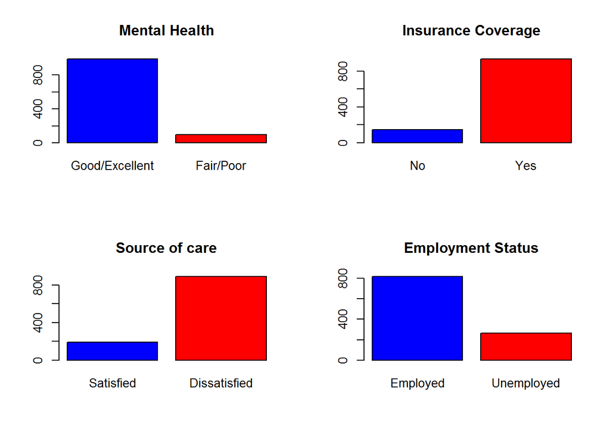

```r
par(mfrow = c(2, 2))
barplot(table(MNHPOOR), names.arg = c("Good/Excellent", "Fair/Poor"), col = c("blue",
    "red"), main = "Mental Health")
barplot(table(insure), names.arg = c("No", "Yes"), col = c("blue", "red"), main = "Insurance Coverage")
barplot(table(USC), names.arg = c("Satisfied", "Dissatisfied"), col = c("blue",
    "red"), main = "Source of care")
barplot(table(UNEMPLOY), names.arg = c("Employed", "Unemployed"), col = c("blue",
    "red"), main = "Employment Status")
```

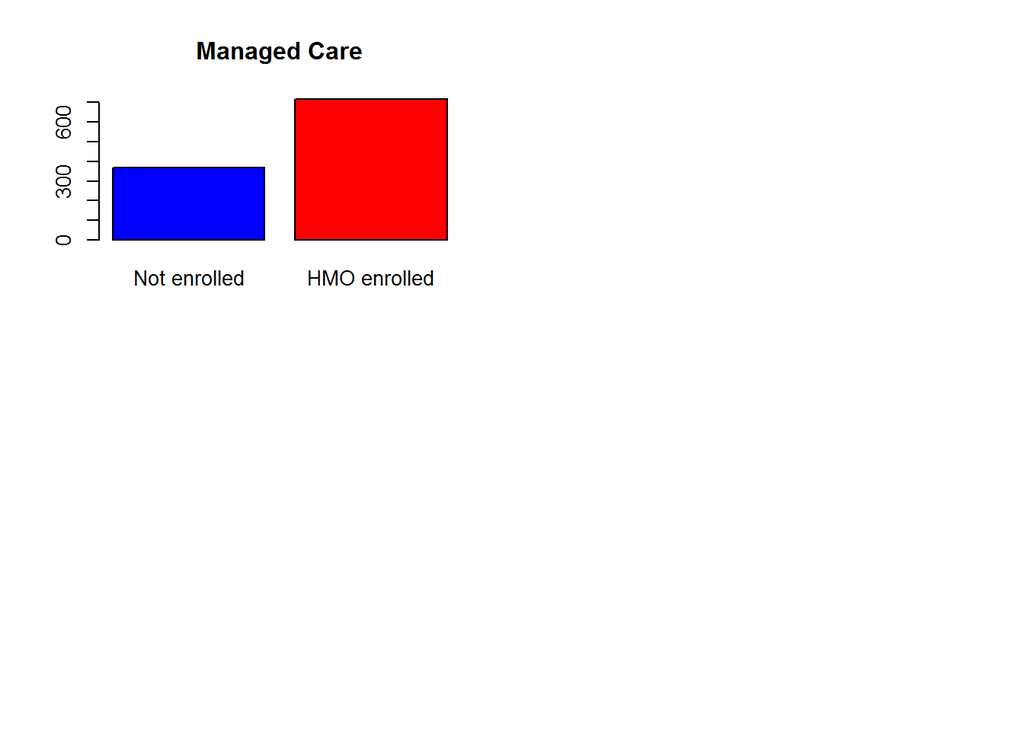

```r
barplot(table(MANAGEDCARE), names.arg = c("Not enrolled", "HMO enrolled"), col = c("blue",
    "red"), main = "Managed Care")
```

#### Correlation Analysis by plotting scatterplot and correlation matrix

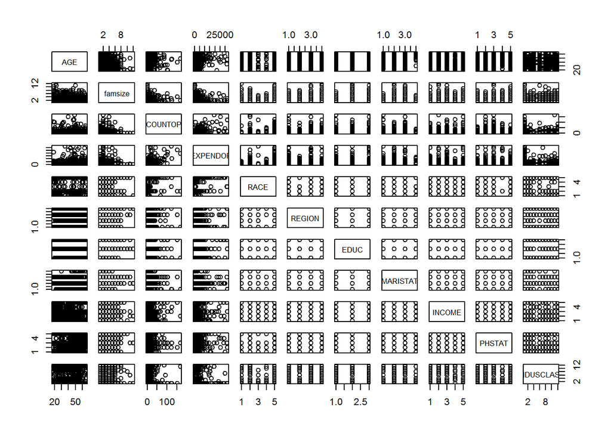

```r
# pairwise scatterplot after removing binary variables
pwdata <- subset(OppHealth_train, select = -c(GENDER, ANYLIMIT, COLLEGE, HIGHSCH,
    MNHPOOR, insure, USC, UNEMPLOY, MANAGEDCARE))
pairs(pwdata)
```

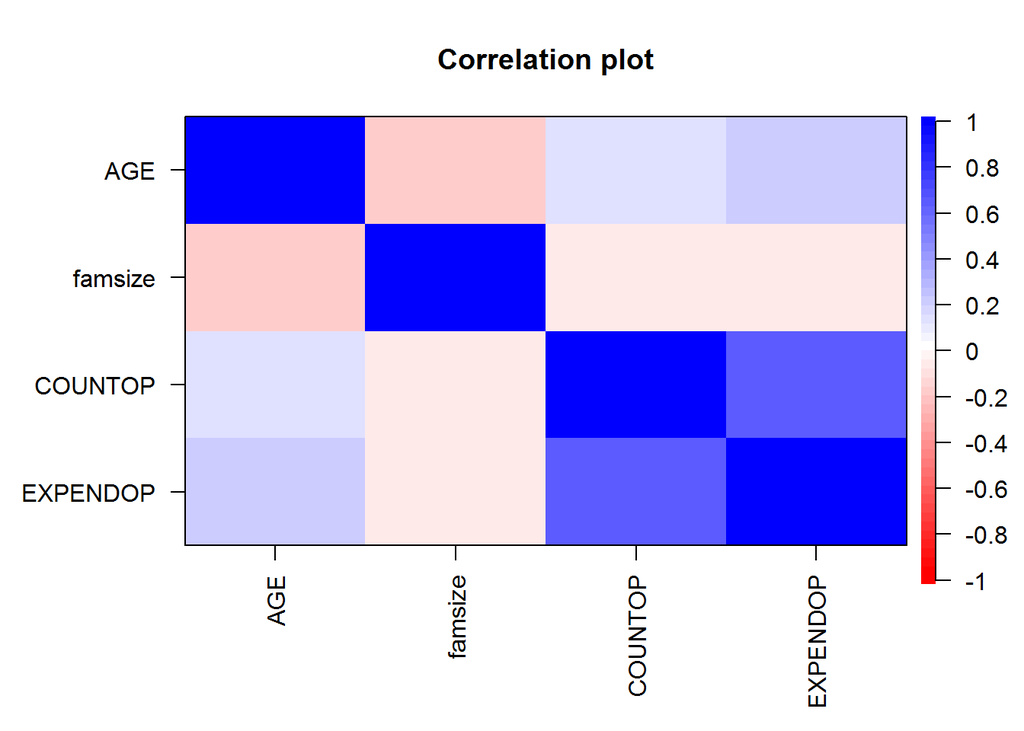

```r
# correlation between continous variables
library(corrplot)
d <- subset(OppHealth_train, select = c(AGE, famsize, COUNTOP, EXPENDOP))
d1 <- cor(d)

corPlot(d)
```

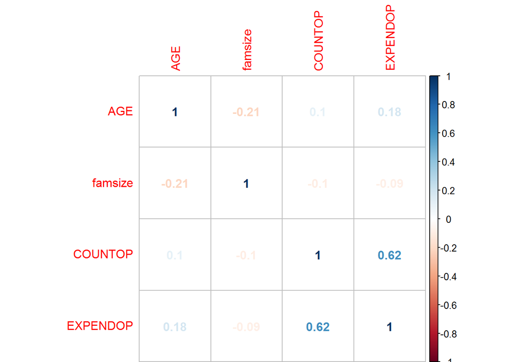

```r
corrplot(d1, method = "number")
```

Combining all three plots it clear there is pairwise collinearity only between countop and expendop which implies that count of out pateints is expected to be significant in explaining outpatients expenditure.

### Regression Analysis

We began with a sinple linear regression with *EXPENDOP* as dependent variable and rest others as independent variables and ran our first model with following results.

```r
model.fit1 <- lm(EXPENDOP ~ AGE + factor(ANYLIMIT) + factor(COLLEGE) + factor(HIGHSCH) +
    factor(GENDER) + factor(MNHPOOR) + factor(insure) + factor(USC) + factor(UNEMPLOY) +
    factor(MANAGEDCARE) + famsize + COUNTOP + RACE + REGION + EDUC + MARISTAT +
    INCOME + PHSTAT + INDUSCLASS, data = OppHealth_train)
summary(model.fit1)
```

```
##
## Call:
## lm(formula = EXPENDOP ~ AGE + factor(ANYLIMIT) + factor(COLLEGE) +
##     factor(HIGHSCH) + factor(GENDER) + factor(MNHPOOR) + factor(insure) +
##     factor(USC) + factor(UNEMPLOY) + factor(MANAGEDCARE) + famsize +
##     COUNTOP + RACE + REGION + EDUC + MARISTAT + INCOME + PHSTAT +
##     INDUSCLASS, data = OppHealth_train)
##
## Residuals:
##      Min       1Q   Median       3Q      Max
## -12106.0   -955.5   -356.8    396.3  24716.1
##
## Coefficients: (2 not defined because of singularities)
##                        Estimate Std. Error t value Pr(>|t|)
## (Intercept)           -1643.057    792.251  -2.074 0.038333 *
## AGE                      27.353      7.883   3.470 0.000542 ***
## factor(ANYLIMIT)1       422.996    212.997   1.986 0.047304 *
## factor(COLLEGE)1        -94.052    262.082  -0.359 0.719768
## factor(HIGHSCH)1       -206.522    224.945  -0.918 0.358780
## factor(GENDER)1          30.405    184.856   0.164 0.869387
## factor(MNHPOOR)1         13.416    325.910   0.041 0.967174
## factor(insure)1         703.091    299.007   2.351 0.018888 *
## factor(USC)1            280.117    229.572   1.220 0.222677
## factor(UNEMPLOY)1       125.137    261.192   0.479 0.631968
## factor(MANAGEDCARE)1    -13.590    219.340  -0.062 0.950609
## famsize                  11.606     57.545   0.202 0.840197
## COUNTOP                 136.415      5.977  22.822  < 2e-16 ***
## RACEBLACK               222.330    463.114   0.480 0.631274
## RACENATIV              4810.606    880.659   5.463 5.87e-08 ***
## RACEOTHER               115.732    718.492   0.161 0.872064
## RACEWHITE               274.861    410.135   0.670 0.502898
## REGIONNORTHEAST        -842.439    273.048  -3.085 0.002087 **
## REGIONSOUTH            -587.641    228.674  -2.570 0.010315 *
## REGIONWEST             -522.763    245.859  -2.126 0.033716 *
## EDUCHIGHSCH                  NA         NA      NA       NA
## EDUCLHIGHSC                  NA         NA      NA       NA
## MARISTATMARRIED         192.791    266.402   0.724 0.469423
## MARISTATNEVMAR          177.086    299.298   0.592 0.554200
## MARISTATWIDOWED        -152.416    582.497  -0.262 0.793635
## INCOMELINCOME           444.576    287.042   1.549 0.121729
```

[output cut: 9 more lines]

```
## INDUSCLASSMANUFACT       32.697    340.299   0.096 0.923474
## INDUSCLASSMILITARY      -22.244   1577.680  -0.014 0.988754
## INDUSCLASSMINCONST     -268.741    527.369  -0.510 0.610447
## INDUSCLASSNATRESOURCE  2787.006    772.318   3.609 0.000322 ***
## INDUSCLASSOTHERSERV     306.158    482.467   0.635 0.525850
## INDUSCLASSPROFSERV      101.871    362.025   0.281 0.778466
## INDUSCLASSPUBADMIN      572.755    497.923   1.150 0.250290
## INDUSCLASSSALES         201.958    300.707   0.672 0.501981
## INDUSCLASSTRANSINFO    -124.413    410.910  -0.303 0.762122
## ---
## Signif. codes:  0 '***' 0.001 '**' 0.01 '*' 0.05 '.' 0.1 ' ' 1
##
## Residual standard error: 2670 on 1040 degrees of freedom
## Multiple R-squared:  0.4437, Adjusted R-squared:  0.4217
## F-statistic: 20.23 on 41 and 1040 DF,  p-value: < 2.2e-16
```

Before improving this model with checked for our dependent variable.

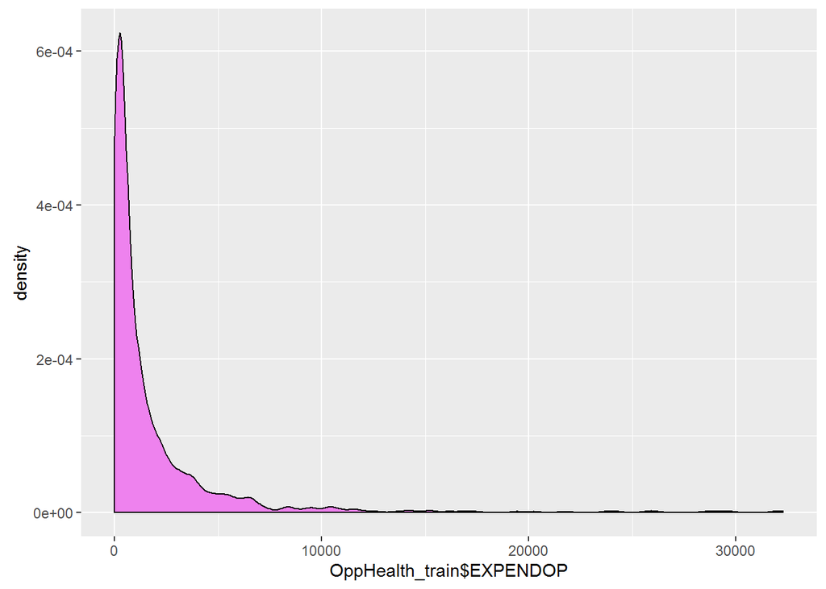

```r
library(ggplot2)
dat <- data.frame(x = OppHealth_train$EXPENDOP)
ggplot(dat, aes(x = OppHealth_train$EXPENDOP)) + geom_density(fill = "violet")
```

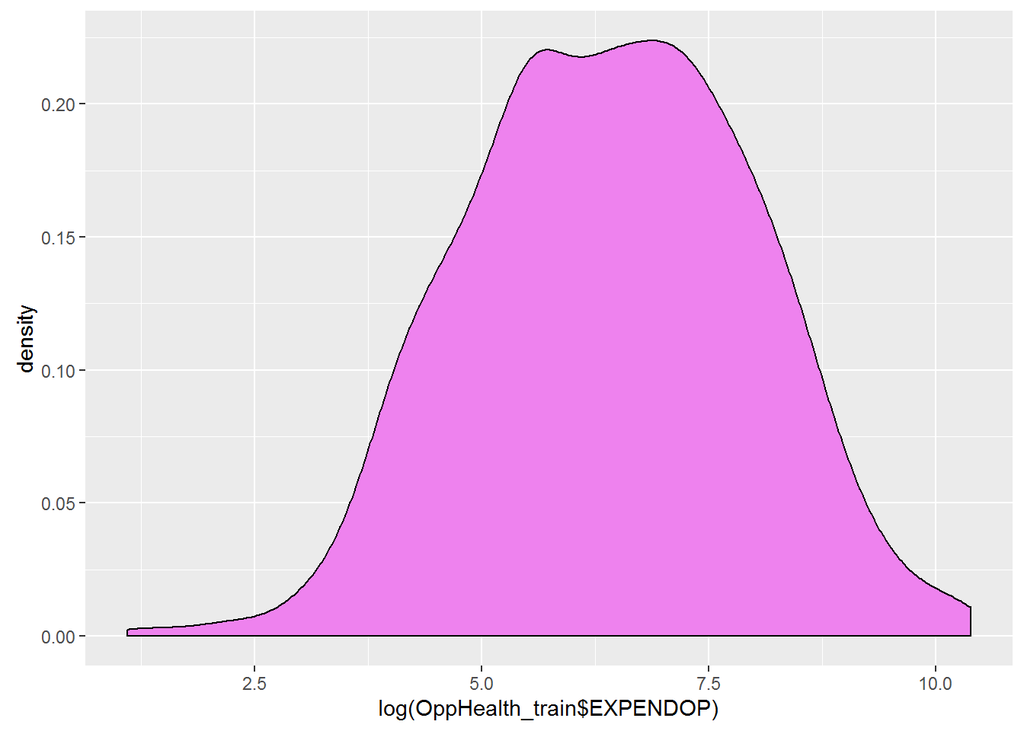

```r
dat <- data.frame(x = log(OppHealth_train$EXPENDOP))
ggplot(dat, aes(x = log(OppHealth_train$EXPENDOP))) + geom_density(fill = "violet")
```

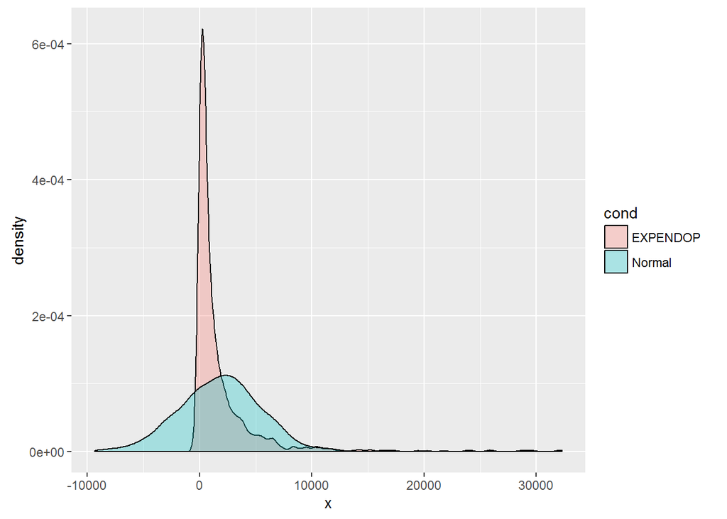

```r
norm <- rnorm(1082, mean = mean(OppHealth_train$EXPENDOP), sd = sd(OppHealth_train$EXPENDOP))
dat <- data.frame(cond = factor(rep(c("EXPENDOP", "Normal"), each = 1082)),
    x = c(OppHealth_train$EXPENDOP, norm))
ggplot(dat, aes(x, fill = cond)) + geom_density(alpha = 0.3)
```

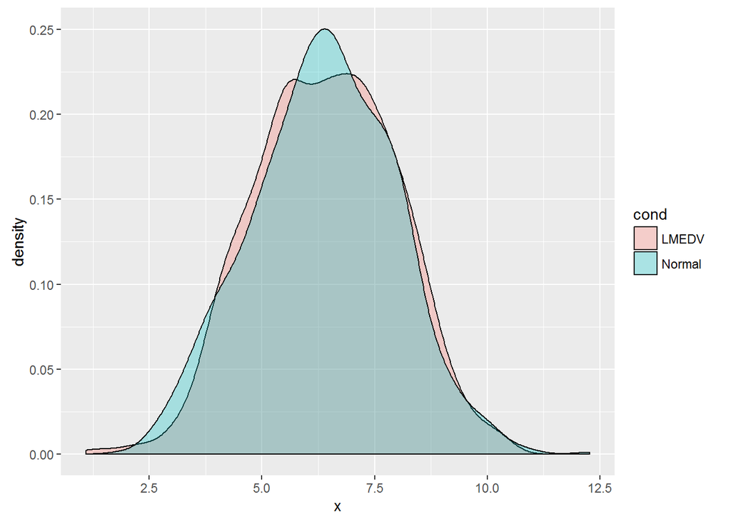

```r
lnorm <- rnorm(1082, mean = mean(log(OppHealth_train$EXPENDOP)), sd = sd(log(OppHealth_train$EXPENDOP)))
dat <- data.frame(cond = factor(rep(c("LMEDV", "Normal"), each = 1082)), x = c(log(OppHealth_train$EXPENDOP),
    lnorm))
ggplot(dat, aes(x, fill = cond)) + geom_density(alpha = 0.3)
```

From very first it is clear that DV is highly right skewed, same we observed in our earlier exploratory analysis as well, in order to remove skewness we tranformed it in logarithm and can be seen that after tranformation DV is normally distributed. In all our next fitted model we will use *LOG(EXPENDOP)* as dependent variable(DV).

We ran our next improved model

```r
model.fit2 <- lm(log(EXPENDOP) ~ AGE + factor(ANYLIMIT) + factor(COLLEGE) +
    factor(HIGHSCH) + factor(GENDER) + factor(MNHPOOR) + factor(insure) + factor(USC) +
    factor(UNEMPLOY) + factor(MANAGEDCARE) + famsize + COUNTOP + RACE + REGION +
    EDUC + MARISTAT + INCOME + PHSTAT + INDUSCLASS, data = OppHealth_train)
summary(model.fit2)
```

```
##
## Call:
## lm(formula = log(EXPENDOP) ~ AGE + factor(ANYLIMIT) + factor(COLLEGE) +
##     factor(HIGHSCH) + factor(GENDER) + factor(MNHPOOR) + factor(insure) +
##     factor(USC) + factor(UNEMPLOY) + factor(MANAGEDCARE) + famsize +
##     COUNTOP + RACE + REGION + EDUC + MARISTAT + INCOME + PHSTAT +
##     INDUSCLASS, data = OppHealth_train)
##
## Residuals:
##     Min      1Q  Median      3Q     Max
## -4.5502 -0.7854  0.0253  0.8257  3.6067
##
## Coefficients: (2 not defined because of singularities)
##                        Estimate Std. Error t value Pr(>|t|)
## (Intercept)            3.439269   0.367749   9.352  < 2e-16 ***
## AGE                    0.021159   0.003659   5.782 9.75e-09 ***
## factor(ANYLIMIT)1      0.263236   0.098869   2.662  0.00788 **
## factor(COLLEGE)1       0.088970   0.121654   0.731  0.46474
## factor(HIGHSCH)1      -0.011565   0.104415  -0.111  0.91183
## factor(GENDER)1        0.159702   0.085807   1.861  0.06300 .
## factor(MNHPOOR)1       0.181564   0.151281   1.200  0.23035
## factor(insure)1        0.583214   0.138794   4.202 2.87e-05 ***
## factor(USC)1           0.198357   0.106563   1.861  0.06297 .
## factor(UNEMPLOY)1     -0.047857   0.121241  -0.395  0.69312
## factor(MANAGEDCARE)1   0.100539   0.101814   0.987  0.32364
## famsize               -0.030361   0.026711  -1.137  0.25594
## COUNTOP                0.045462   0.002775  16.385  < 2e-16 ***
## RACEBLACK              0.494361   0.214970   2.300  0.02166 *
## RACENATIV              0.711905   0.408786   1.742  0.08189 .
## RACEOTHER              0.759974   0.333511   2.279  0.02289 *
## RACEWHITE              0.613699   0.190378   3.224  0.00131 **
## REGIONNORTHEAST       -0.172510   0.126744  -1.361  0.17378
## REGIONSOUTH           -0.159475   0.106146  -1.502  0.13330
## REGIONWEST            -0.073211   0.114123  -0.642  0.52133
## EDUCHIGHSCH                  NA         NA      NA       NA
## EDUCLHIGHSC                  NA         NA      NA       NA
## MARISTATMARRIED        0.058658   0.123659   0.474  0.63535
## MARISTATNEVMAR         0.094193   0.138929   0.678  0.49793
## MARISTATWIDOWED       -0.063719   0.270385  -0.236  0.81374
## INCOMELINCOME          0.114657   0.133240   0.861  0.38969
```

[output cut: 9 more lines]

```
## INDUSCLASSMANUFACT    -0.050453   0.157961  -0.319  0.74949
## INDUSCLASSMILITARY    -0.201245   0.732331  -0.275  0.78352
## INDUSCLASSMINCONST    -0.054644   0.244795  -0.223  0.82341
## INDUSCLASSNATRESOURCE  0.707928   0.358496   1.975  0.04856 *
## INDUSCLASSOTHERSERV    0.028416   0.223953   0.127  0.89906
## INDUSCLASSPROFSERV    -0.010284   0.168046  -0.061  0.95121
## INDUSCLASSPUBADMIN     0.409152   0.231127   1.770  0.07698 .
## INDUSCLASSSALES       -0.025731   0.139583  -0.184  0.85378
## INDUSCLASSTRANSINFO   -0.145932   0.190737  -0.765  0.44439
## ---
## Signif. codes:  0 '***' 0.001 '**' 0.01 '*' 0.05 '.' 0.1 ' ' 1
##
## Residual standard error: 1.239 on 1040 degrees of freedom
## Multiple R-squared:  0.3871, Adjusted R-squared:  0.363
## F-statistic: 16.02 on 41 and 1040 DF,  p-value: < 2.2e-16
```

### Checking Multicollinearity

Before further improvement we checked for **Multicollinearity** in this model. From out pairwise scatter plot it was clear that none of the variables are correlated with each other and plots are completely scattered. However, to be assured that our model is free from multicollinearity we performed statistics test *VIF*. If VIF = 1 no correlation, 38 highly correlated.

```r
vif(lm(log(EXPENDOP) ~ AGE + factor(ANYLIMIT) + factor(COLLEGE) + factor(HIGHSCH) +
    factor(GENDER) + factor(MNHPOOR) + factor(insure) + factor(USC) + factor(UNEMPLOY) +
    factor(MANAGEDCARE) + famsize + COUNTOP + RACE + REGION + MARISTAT + INCOME +
    PHSTAT + INDUSCLASS, data = OppHealth_train))
```

```
##                         GVIF Df GVIF^(1/(2*Df))
## AGE                 1.612892  1        1.269997
## factor(ANYLIMIT)    1.407756  1        1.186489
## factor(COLLEGE)     2.235940  1        1.495306
## factor(HIGHSCH)     1.888968  1        1.374397
## factor(GENDER)      1.243161  1        1.114971
## factor(MNHPOOR)     1.303597  1        1.141752
## factor(insure)      1.611509  1        1.269452
## factor(USC)         1.177212  1        1.084994
## factor(UNEMPLOY)    1.924816  1        1.387377
## factor(MANAGEDCARE) 1.636842  1        1.279391
## famsize             1.343655  1        1.159161
## COUNTOP             1.171693  1        1.082448
## RACE                1.328190  4        1.036114
## REGION              1.235038  3        1.035810
## MARISTAT            1.831971  3        1.106165
## INCOME              2.015213  4        1.091541
## PHSTAT              1.698892  4        1.068491
## INDUSCLASS          2.485397 11        1.042252
```

As we can see all VIF are either 1 or 2 hence there is no collinearity in our model.

#### Parsimonious Modelling

As we have seen in our last model that all the regressors are not significant, hence we should be selecting only significant variables, for this we have used * Forward Selection * Backward Selection * Step Selection

```r
model.base <- lm(log(EXPENDOP) ~ AGE, data = OppHealth_train)
# Forward Selection
step(model.base, scope = list(upper = model.fit2, lower ~ 1), direction = "forward",
    trace = FALSE)
```

```
##
## Call:
## lm(formula = log(EXPENDOP) ~ AGE + COUNTOP + factor(insure) +
##     PHSTAT + RACE + factor(ANYLIMIT) + factor(USC) + factor(GENDER),
##     data = OppHealth_train)
##
## Coefficients:
##       (Intercept)                AGE            COUNTOP
##           3.51555            0.01882            0.04629
##   factor(insure)1         PHSTATFAIR         PHSTATGOOD
##           0.67208            0.50319            0.25999
##        PHSTATPOOR         PHSTATVGOO          RACEBLACK
##           0.79131            0.22477            0.47957
##         RACENATIV          RACEOTHER          RACEWHITE
##           0.77289            0.85995            0.62407
## factor(ANYLIMIT)1       factor(USC)1    factor(GENDER)1
##           0.26989            0.19810            0.14825
```

```r
# Backward Selection
step(model.fit2, direction = "backward", trace = FALSE)
```

```
##
## Call:
## lm(formula = log(EXPENDOP) ~ AGE + factor(ANYLIMIT) + factor(GENDER) +
##     factor(insure) + factor(USC) + COUNTOP + RACE + PHSTAT, data = OppHealth_train)
##
## Coefficients:
##       (Intercept)                AGE  factor(ANYLIMIT)1
##           3.51555            0.01882            0.26989
##   factor(GENDER)1    factor(insure)1       factor(USC)1
##           0.14825            0.67208            0.19810
##           COUNTOP          RACEBLACK          RACENATIV
##           0.04629            0.47957            0.77289
##         RACEOTHER          RACEWHITE         PHSTATFAIR
##           0.85995            0.62407            0.50319
##        PHSTATGOOD         PHSTATPOOR         PHSTATVGOO
##           0.25999            0.79131            0.22477
```

```r
# Stepwise Selection-Both
step(model.base, scope = list(upper = model.fit2, lower ~ 1), direction = "both",
    trace = FALSE)
```

```
##
## Call:
## lm(formula = log(EXPENDOP) ~ AGE + COUNTOP + factor(insure) +
##     PHSTAT + RACE + factor(ANYLIMIT) + factor(USC) + factor(GENDER),
##     data = OppHealth_train)
##
## Coefficients:
##       (Intercept)                AGE            COUNTOP
##           3.51555            0.01882            0.04629
##   factor(insure)1         PHSTATFAIR         PHSTATGOOD
##           0.67208            0.50319            0.25999
##        PHSTATPOOR         PHSTATVGOO          RACEBLACK
##           0.79131            0.22477            0.47957
##         RACENATIV          RACEOTHER          RACEWHITE
##           0.77289            0.85995            0.62407
## factor(ANYLIMIT)1       factor(USC)1    factor(GENDER)1
##           0.26989            0.19810            0.14825
```

```r
model.fit3 <- lm(log(EXPENDOP) ~ AGE + COUNTOP + famsize + factor(insure) +
    factor(GENDER) + factor(ANYLIMIT) + factor(USC) + PHSTAT + RACE + INCOME,
    data = OppHealth_train)
summary(model.fit3)
```

```
##
## Call:
## lm(formula = log(EXPENDOP) ~ AGE + COUNTOP + famsize + factor(insure) +
##     factor(GENDER) + factor(ANYLIMIT) + factor(USC) + PHSTAT +
##     RACE + INCOME, data = OppHealth_train)
##
## Residuals:
##     Min      1Q  Median      3Q     Max
## -4.5976 -0.7949  0.0138  0.8209  3.4033
##
## Coefficients:
##                    Estimate Std. Error t value Pr(>|t|)
## (Intercept)        3.549960   0.283006  12.544  < 2e-16 ***
## AGE                0.018864   0.003143   6.002 2.68e-09 ***
## COUNTOP            0.046104   0.002734  16.866  < 2e-16 ***
## famsize           -0.032110   0.024372  -1.317 0.187961
## factor(insure)1    0.685631   0.115814   5.920 4.34e-09 ***
## factor(GENDER)1    0.141682   0.079084   1.792 0.073491 .
## factor(ANYLIMIT)1  0.244255   0.095611   2.555 0.010767 *
## factor(USC)1       0.208406   0.103935   2.005 0.045200 *
## PHSTATFAIR         0.469270   0.147061   3.191 0.001459 **
## PHSTATGOOD         0.239760   0.109439   2.191 0.028683 *
## PHSTATPOOR         0.741164   0.204898   3.617 0.000312 ***
## PHSTATVGOO         0.223837   0.105660   2.118 0.034367 *
## RACEBLACK          0.436050   0.208964   2.087 0.037152 *
## RACENATIV          0.702631   0.405941   1.731 0.083765 .
## RACEOTHER          0.813090   0.329330   2.469 0.013708 *
## RACEWHITE          0.606331   0.187388   3.236 0.001251 **
## INCOMELINCOME      0.059075   0.123757   0.477 0.633213
## INCOMEMINCOME      0.159615   0.097294   1.641 0.101189
## INCOMENPOOR        0.159923   0.181584   0.881 0.378671
## INCOMEPOOR         0.182651   0.127935   1.428 0.153677
## ---
## Signif. codes:  0 '***' 0.001 '**' 0.01 '*' 0.05 '.' 0.1 ' ' 1
##
## Residual standard error: 1.237 on 1062 degrees of freedom
## Multiple R-squared:  0.3762, Adjusted R-squared:  0.3651
## F-statistic: 33.71 on 19 and 1062 DF,  p-value: < 2.2e-16
```

### Residual Analysis of model.fit3

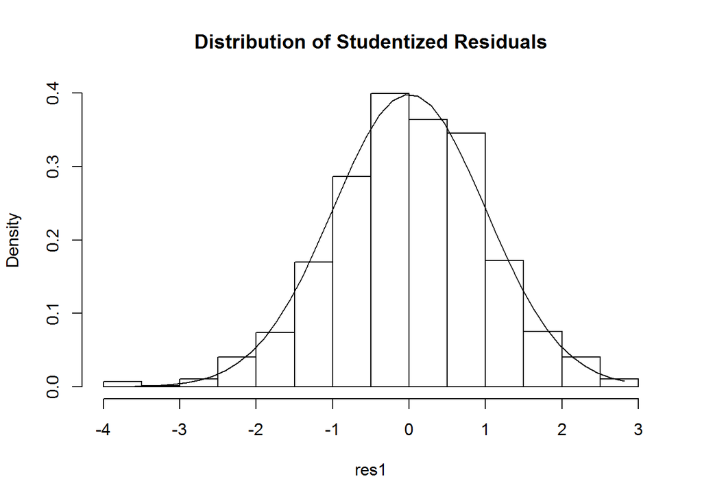

```r
res1 <- studres(model.fit3)
hist(res1, freq = FALSE, main = "Distribution of Studentized Residuals")
xfit <- seq(min(res1), max(res1), length = 40)
yfit <- dnorm(xfit)
lines(xfit, yfit)
```

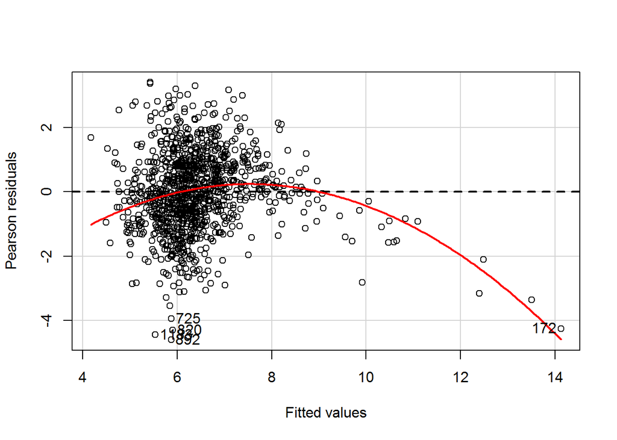

```r
library(car)

residualPlot(model.fit3, id.n = 5)
```

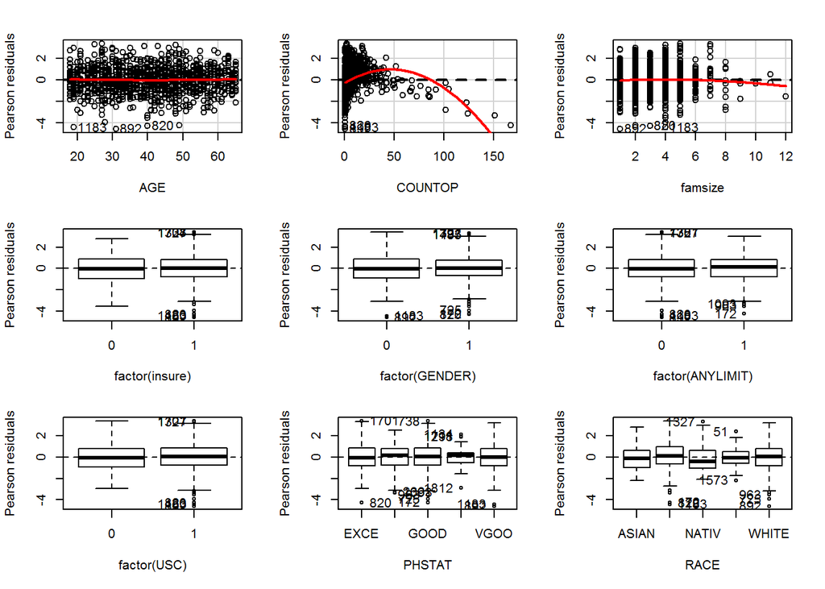

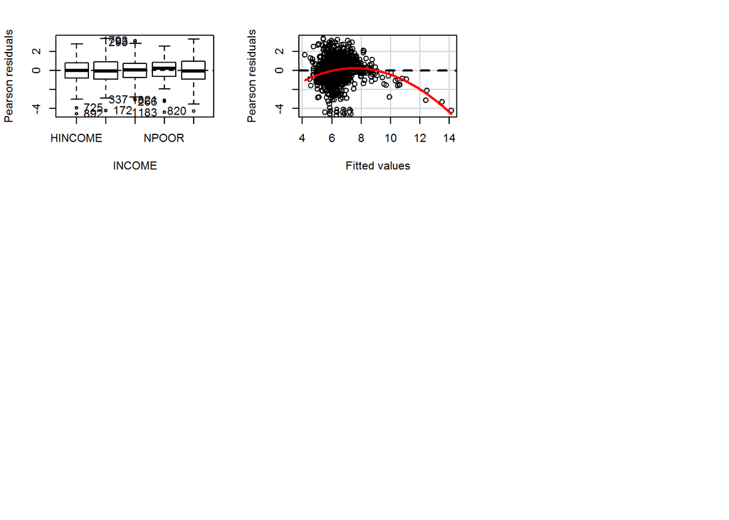

```
##                  Test stat Pr(>|t|)
## AGE                  0.685    0.493
## COUNTOP            -12.834    0.000
## famsize             -1.174    0.241
## factor(insure)          NA       NA
## factor(GENDER)          NA       NA
## factor(ANYLIMIT)        NA       NA
## factor(USC)             NA       NA
## PHSTAT                  NA       NA
## RACE                    NA       NA
## INCOME                  NA       NA
## Tukey test         -11.517    0.000
```

```r
residualPlots(model.fit3, id.n = 3)
```

We can see that residuals are not normally distributed hence contradicting one of our basic assumption in linear regression. Also from regressor vs residuals plot we can see that plot for **COUNTOP** is skewed and also posses some quadratic relation. Hence we need to transform COUNTOP COUNTOP- log(COUNTOP)

```r
model.fit4 <- lm(log(EXPENDOP) ~ AGE + log(COUNTOP) + famsize + factor(insure) +
    factor(GENDER) + factor(ANYLIMIT) + factor(USC) + PHSTAT + RACE + INCOME,
    data = OppHealth_train)
summary(model.fit4)
```

```
##
## Call:
## lm(formula = log(EXPENDOP) ~ AGE + log(COUNTOP) + famsize + factor(insure) +
##     factor(GENDER) + factor(ANYLIMIT) + factor(USC) + PHSTAT +
##     RACE + INCOME, data = OppHealth_train)
##
## Residuals:
##     Min      1Q  Median      3Q     Max
## -3.6564 -0.6230 -0.0460  0.5417  3.8503
##
## Coefficients:
##                    Estimate Std. Error t value Pr(>|t|)
## (Intercept)        3.780076   0.228206  16.564  < 2e-16 ***
## AGE                0.010268   0.002550   4.027 6.06e-05 ***
## log(COUNTOP)       0.994663   0.031271  31.807  < 2e-16 ***
## famsize           -0.002095   0.019675  -0.107   0.9152
## factor(insure)1    0.415357   0.093812   4.428 1.05e-05 ***
## factor(GENDER)1   -0.094111   0.064408  -1.461   0.1443
## factor(ANYLIMIT)1  0.022275   0.077259   0.288   0.7732
## factor(USC)1      -0.041438   0.084237  -0.492   0.6229
## PHSTATFAIR         0.221633   0.118916   1.864   0.0626 .
## PHSTATGOOD         0.083317   0.088426   0.942   0.3463
## PHSTATPOOR         0.360227   0.165869   2.172   0.0301 *
## PHSTATVGOO         0.104970   0.085262   1.231   0.2185
## RACEBLACK          0.338479   0.168428   2.010   0.0447 *
## RACENATIV          0.665112   0.326900   2.035   0.0421 *
## RACEOTHER          0.285450   0.266278   1.072   0.2840
## RACEWHITE          0.330878   0.151394   2.186   0.0291 *
## INCOMELINCOME      0.153032   0.099790   1.534   0.1254
## INCOMEMINCOME      0.127223   0.078410   1.623   0.1050
## INCOMENPOOR       -0.029145   0.146526  -0.199   0.8424
## INCOMEPOOR         0.184342   0.103084   1.788   0.0740 .
## ---
## Signif. codes:  0 '***' 0.001 '**' 0.01 '*' 0.05 '.' 0.1 ' ' 1
##
## Residual standard error: 0.997 on 1062 degrees of freedom
## Multiple R-squared:  0.595,  Adjusted R-squared:  0.5877
## F-statistic: 82.11 on 19 and 1062 DF,  p-value: < 2.2e-16
```

**We can see drastic improvement in R sq of 20% almost, also R sq and adjusted R sq are same.** We will further analyse the residuals of this model.

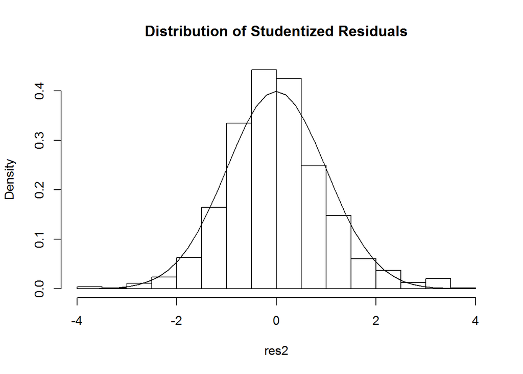

```r
res2 <- studres(model.fit4)
hist(res2, freq = FALSE, main = "Distribution of Studentized Residuals")
xfit <- seq(min(res2), max(res2), length = 40)
yfit <- dnorm(xfit)
lines(xfit, yfit)
```

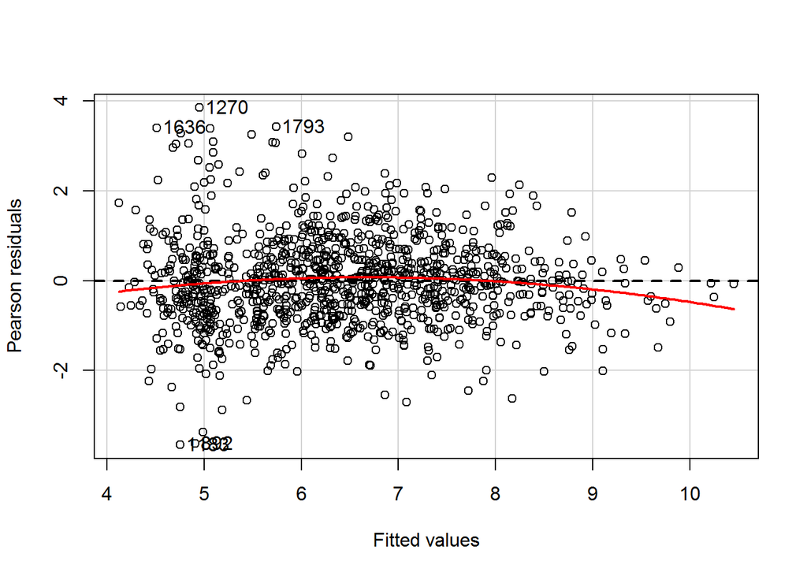

```r
library(car)
residualPlot(model.fit4, id.n = 5)
```

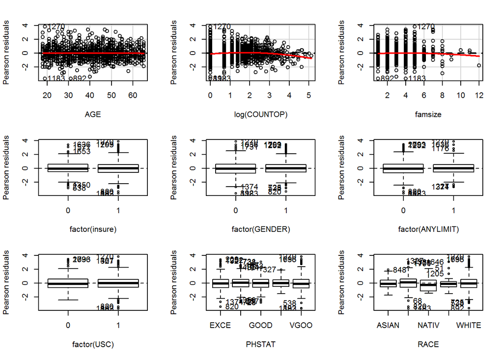

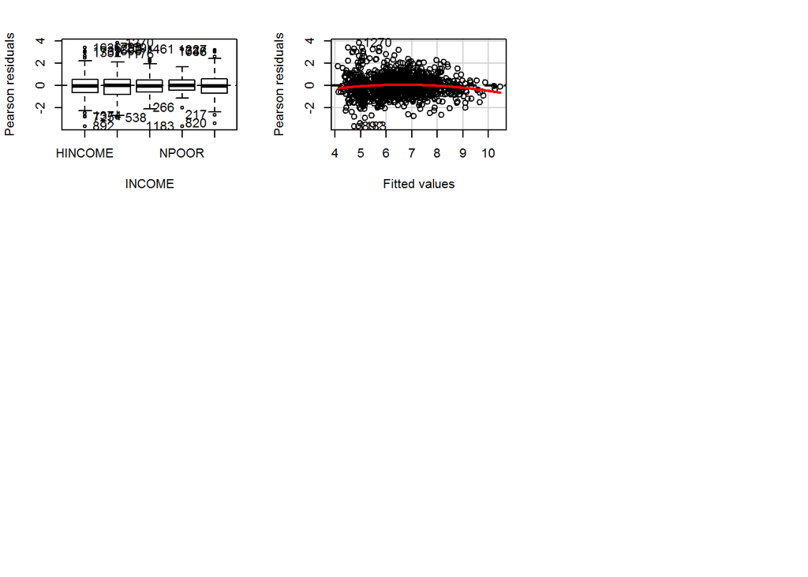

```
##                  Test stat Pr(>|t|)
## AGE                 -0.182    0.855
## log(COUNTOP)        -3.676    0.000
## famsize             -1.037    0.300
## factor(insure)          NA       NA
## factor(GENDER)          NA       NA
## factor(ANYLIMIT)        NA       NA
## factor(USC)             NA       NA
## PHSTAT                  NA       NA
## RACE                    NA       NA
## INCOME                  NA       NA
## Tukey test          -3.015    0.003
```

```r
residualPlots(model.fit4, id.n = 3)
```

```r
model.fit5 <- lm(log(EXPENDOP) ~ AGE + log(COUNTOP) + I(log(COUNTOP) * log(COUNTOP)) +
    famsize + factor(insure) + factor(GENDER) + factor(ANYLIMIT) + factor(USC) +
    PHSTAT + RACE + INCOME, data = OppHealth_train)
summary(model.fit5)
```

```
##
## Call:
## lm(formula = log(EXPENDOP) ~ AGE + log(COUNTOP) + I(log(COUNTOP) *
##     log(COUNTOP)) + famsize + factor(insure) + factor(GENDER) +
##     factor(ANYLIMIT) + factor(USC) + PHSTAT + RACE + INCOME,
##     data = OppHealth_train)
##
## Residuals:
##     Min      1Q  Median      3Q     Max
## -3.5297 -0.6210 -0.0510  0.5559  3.9387
##
## Coefficients:
##                                  Estimate Std. Error t value Pr(>|t|)
## (Intercept)                     3.7532641  0.2269904  16.535  < 2e-16 ***
## AGE                             0.0093415  0.0025475   3.667 0.000258 ***
## log(COUNTOP)                    1.2600512  0.0785954  16.032  < 2e-16 ***
## I(log(COUNTOP) * log(COUNTOP)) -0.0765055  0.0208095  -3.676 0.000248 ***
## famsize                        -0.0003176  0.0195663  -0.016 0.987054
## factor(insure)1                 0.3820231  0.0937039   4.077  4.9e-05 ***
## factor(GENDER)1                -0.1106514  0.0641896  -1.724 0.085032 .
## factor(ANYLIMIT)1               0.0536160  0.0772792   0.694 0.487963
## factor(USC)1                   -0.0732609  0.0841911  -0.870 0.384402
## PHSTATFAIR                      0.2211893  0.1182216   1.871 0.061624 .
## PHSTATGOOD                      0.0832496  0.0879099   0.947 0.343861
## PHSTATPOOR                      0.3700548  0.1649215   2.244 0.025049 *
## PHSTATVGOO                      0.1002115  0.0847742   1.182 0.237431
## RACEBLACK                       0.3379210  0.1674438   2.018 0.043830 *
## RACENATIV                       0.6804260  0.3250167   2.094 0.036540 *
## RACEOTHER                       0.2945996  0.2647343   1.113 0.266041
## RACEWHITE                       0.3131122  0.1505871   2.079 0.037832 *
## INCOMELINCOME                   0.1564763  0.0992119   1.577 0.115049
## INCOMEMINCOME                   0.1285252  0.0779526   1.649 0.099493 .
## INCOMENPOOR                    -0.0480432  0.1457605  -0.330 0.741765
## INCOMEPOOR                      0.1803329  0.1024874   1.760 0.078770 .
## ---
## Signif. codes:  0 '***' 0.001 '**' 0.01 '*' 0.05 '.' 0.1 ' ' 1
##
## Residual standard error: 0.9911 on 1061 degrees of freedom
## Multiple R-squared:  0.6001, Adjusted R-squared:  0.5925
## F-statistic:  79.6 on 20 and 1061 DF,  p-value: < 2.2e-16
```

We tried transforming log(COUTNOP) to capture its small quadtratic relation but do not found any significant improvement inthe model, hence till now our best model is **model.fit4**.

#### Checking Autocorrelation

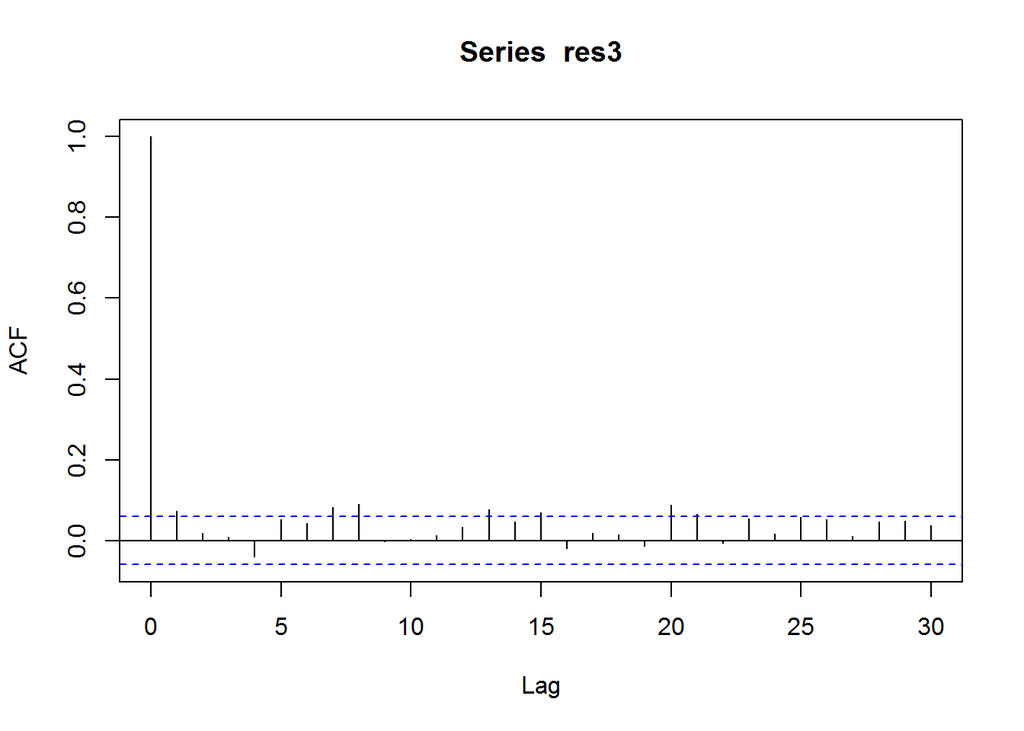

```r
res3 <- residuals(model.fit4)
acf(res3)
```

```r
library(lmtest)
dwtest(model.fit4, alt = "two.sided")
```

```
##
##  Durbin-Watson test
##
## data:  model.fit4
## DW = 1.8543, p-value = 0.01586
## alternative hypothesis: true autocorrelation is not 0
```

From **ACF** plot we can see autocorrelation at **lag1**, also after performing **Durbin Watson Test** p values is less than 0.05 which is confrming autocorrelation at lag1.

In order to remove autocorrelation we will introduce **EXPENDOP** lagged variable by 1 i.e.lag_EXPENDOP.

```r
# Handling auto correlation creating laf 1 variable for expendop
lag_EXPENDOP <- c(0)
for (i in 2:nrow(OppHealth_train)) {
    lag_EXPENDOP[i] <- OppHealth_train$EXPENDOP[i - 1]
}
OppHealth_train <- cbind(OppHealth_train, lag_EXPENDOP)
model.fit5 <- lm(log(EXPENDOP) ~ lag_EXPENDOP + AGE + log(COUNTOP) + famsize +
    factor(insure) + factor(GENDER) + factor(ANYLIMIT) + factor(USC) + PHSTAT +
    RACE + INCOME, data = OppHealth_train)
summary(model.fit5)
```

```
##
## Call:
## lm(formula = log(EXPENDOP) ~ lag_EXPENDOP + AGE + log(COUNTOP) +
##     famsize + factor(insure) + factor(GENDER) + factor(ANYLIMIT) +
##     factor(USC) + PHSTAT + RACE + INCOME, data = OppHealth_train)
##
## Residuals:
##     Min      1Q  Median      3Q     Max
## -3.6316 -0.6156 -0.0419  0.5349  3.8308
##
## Coefficients:
##                     Estimate Std. Error t value Pr(>|t|)
## (Intercept)        3.777e+00  2.282e-01  16.549  < 2e-16 ***
## lag_EXPENDOP       8.650e-06  8.732e-06   0.991   0.3221
## AGE                1.029e-02  2.550e-03   4.034 5.88e-05 ***
## log(COUNTOP)       9.947e-01  3.127e-02  31.809  < 2e-16 ***
## famsize           -2.885e-03  1.969e-02  -0.147   0.8835
## factor(insure)1    4.105e-01  9.394e-02   4.370 1.36e-05 ***
## factor(GENDER)1   -9.232e-02  6.443e-02  -1.433   0.1522
## factor(ANYLIMIT)1  2.164e-02  7.726e-02   0.280   0.7795
## factor(USC)1      -4.332e-02  8.426e-02  -0.514   0.6073
## PHSTATFAIR         2.176e-01  1.190e-01   1.829   0.0677 .
## PHSTATGOOD         8.396e-02  8.843e-02   0.949   0.3426
## PHSTATPOOR         3.575e-01  1.659e-01   2.155   0.0314 *
## PHSTATVGOO         1.048e-01  8.526e-02   1.229   0.2195
## RACEBLACK          3.316e-01  1.686e-01   1.967   0.0494 *
## RACENATIV          6.490e-01  3.273e-01   1.983   0.0477 *
## RACEOTHER          2.810e-01  2.663e-01   1.055   0.2916
## RACEWHITE          3.254e-01  1.515e-01   2.148   0.0319 *
## INCOMELINCOME      1.492e-01  9.987e-02   1.493   0.1356
## INCOMEMINCOME      1.294e-01  7.844e-02   1.650   0.0992 .
## INCOMENPOOR       -3.963e-02  1.469e-01  -0.270   0.7874
## INCOMEPOOR         1.863e-01  1.031e-01   1.807   0.0710 .
## ---
## Signif. codes:  0 '***' 0.001 '**' 0.01 '*' 0.05 '.' 0.1 ' ' 1
##
## Residual standard error: 0.997 on 1061 degrees of freedom
## Multiple R-squared:  0.5954, Adjusted R-squared:  0.5877
## F-statistic: 78.05 on 20 and 1061 DF,  p-value: < 2.2e-16
```

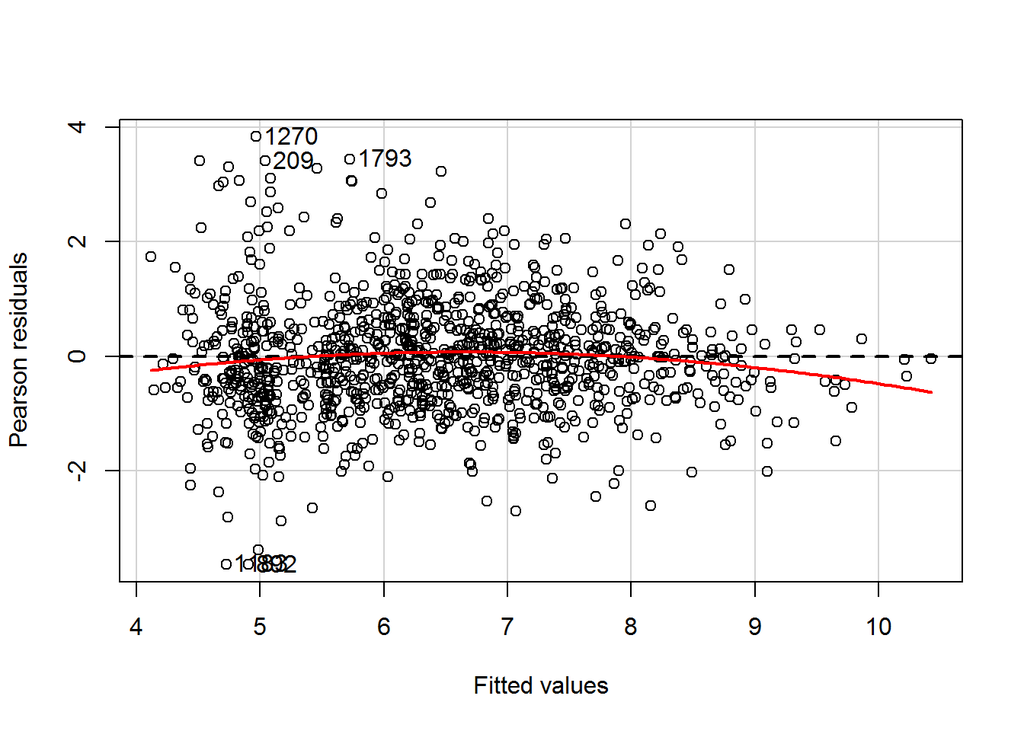

```r
res3 <- residuals(model.fit5)
residualPlot(model.fit5, id.n = 5)
```

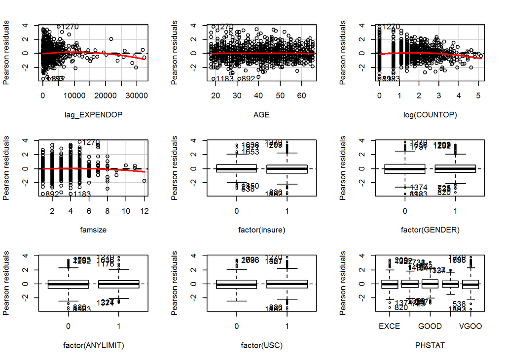

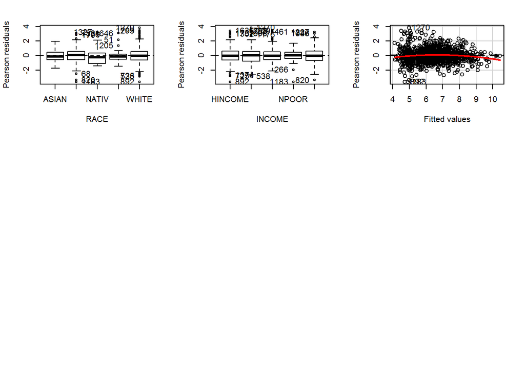

```
##                  Test stat Pr(>|t|)
## lag_EXPENDOP        -2.485    0.013
## AGE                 -0.205    0.838
## log(COUNTOP)        -3.650    0.000
## famsize             -1.075    0.283
## factor(insure)          NA       NA
## factor(GENDER)          NA       NA
## factor(ANYLIMIT)        NA       NA
## factor(USC)             NA       NA
## PHSTAT                  NA       NA
## RACE                    NA       NA
## INCOME                  NA       NA
## Tukey test          -3.014    0.003
```

```r
residualPlots(model.fit5, id.n = 3)
```

We can see skewness in scatter plot of lagged variable hence we will transform it in logarithm.

```r
Llag_EXPENDOP <- c(0)
for (i in 2:nrow(OppHealth_train)) Llag_EXPENDOP[i] <- log(OppHealth_train$lag_EXPENDOP[i])

OppHealth_train <- cbind(OppHealth_train, Llag_EXPENDOP)
model.fit6 <- lm(log(EXPENDOP) ~ Llag_EXPENDOP + AGE + log(COUNTOP) + famsize +
    factor(insure) + factor(GENDER) + factor(ANYLIMIT) + factor(USC) + PHSTAT +
    RACE + INCOME, data = OppHealth_train)
summary(model.fit6)
```

```
##
## Call:
## lm(formula = log(EXPENDOP) ~ Llag_EXPENDOP + AGE + log(COUNTOP) +
##     famsize + factor(insure) + factor(GENDER) + factor(ANYLIMIT) +
##     factor(USC) + PHSTAT + RACE + INCOME, data = OppHealth_train)
##
## Residuals:
##     Min      1Q  Median      3Q     Max
## -3.6749 -0.6095 -0.0386  0.5416  3.7870
##
## Coefficients:
##                    Estimate Std. Error t value Pr(>|t|)
## (Intercept)        3.539699   0.254338  13.917  < 2e-16 ***
## Llag_EXPENDOP      0.041549   0.019542   2.126   0.0337 *
## AGE                0.010437   0.002547   4.098 4.49e-05 ***
## log(COUNTOP)       0.994363   0.031220  31.850  < 2e-16 ***
## famsize           -0.003392   0.019652  -0.173   0.8630
## factor(insure)1    0.405572   0.093770   4.325 1.67e-05 ***
## factor(GENDER)1   -0.090083   0.064329  -1.400   0.1617
## factor(ANYLIMIT)1  0.023032   0.077132   0.299   0.7653
## factor(USC)1      -0.043381   0.084103  -0.516   0.6061
## PHSTATFAIR         0.215183   0.118758   1.812   0.0703 .
## PHSTATGOOD         0.076902   0.088332   0.871   0.3842
## PHSTATPOOR         0.354068   0.165620   2.138   0.0328 *
## PHSTATVGOO         0.099270   0.085164   1.166   0.2440
## RACEBLACK          0.327832   0.168224   1.949   0.0516 .
## RACENATIV          0.674896   0.326391   2.068   0.0389 *
## RACEOTHER          0.269011   0.265950   1.012   0.3120
## RACEWHITE          0.314765   0.151333   2.080   0.0378 *
## INCOMELINCOME      0.139003   0.099844   1.392   0.1642
## INCOMEMINCOME      0.132608   0.078321   1.693   0.0907 .
## INCOMENPOOR       -0.033155   0.146296  -0.227   0.8208
## INCOMEPOOR         0.177995   0.102957   1.729   0.0841 .
## ---
## Signif. codes:  0 '***' 0.001 '**' 0.01 '*' 0.05 '.' 0.1 ' ' 1
##
## Residual standard error: 0.9953 on 1061 degrees of freedom
## Multiple R-squared:  0.5967, Adjusted R-squared:  0.5891
## F-statistic: 78.49 on 20 and 1061 DF,  p-value: < 2.2e-16
```

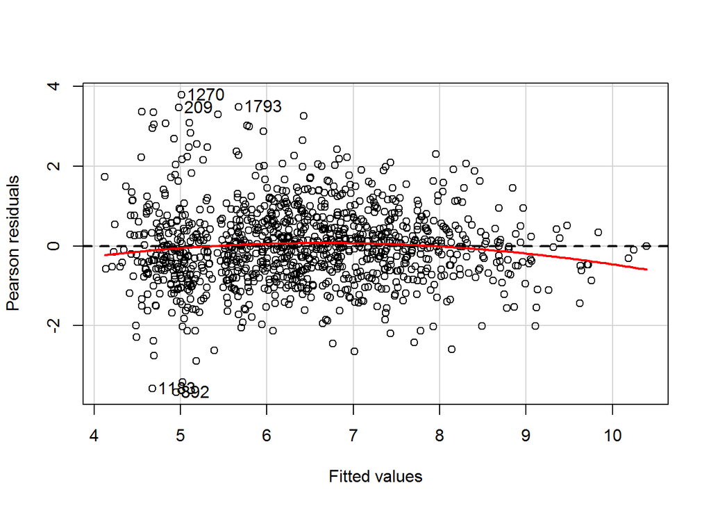

```r
res4 <- residuals(model.fit6)
residualPlot(model.fit6, id.n = 5)
```

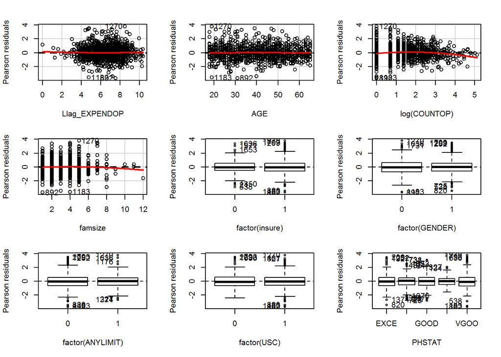

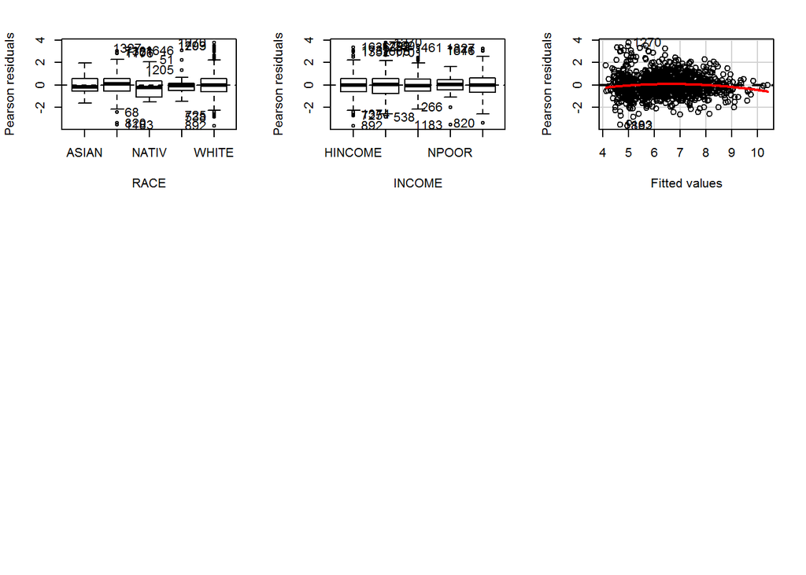

```
##                  Test stat Pr(>|t|)
## Llag_EXPENDOP        0.438    0.662
## AGE                 -0.193    0.847
## log(COUNTOP)        -3.627    0.000
## famsize             -1.126    0.260
## factor(insure)          NA       NA
## factor(GENDER)          NA       NA
## factor(ANYLIMIT)        NA       NA
## factor(USC)             NA       NA
## PHSTAT                  NA       NA
## RACE                    NA       NA
## INCOME                  NA       NA
## Tukey test          -2.933    0.003
```

```r
residualPlots(model.fit6, id.n = 3)
```